# 1.Data science:

```
Data science is the study of data.
It involves developing methods of recording, storing, and analyzing data to effectively extract useful information.
Data science is more closely related to the mathematics field of Statistics.
```

# Data Analytics:

```
Data analytics is the science of analyzing raw data in order to make conclusions about that information.
This information can then be used to optimize processes to increase the overall efficiency of a business or system.
```

# 2.Dataset:

```
a collection of related sets of information that is composed of separate elements but can be manipulated as a unit by a computer is known as dataset.
Eg: Weather data
```

# 3.Dataset Name: sal

```
"sal.csv" is my dataset which contains various variables such as rank, discipline, yrs.since.phd, sex, salary.
a gist of my dataset is it mainly depicts the rank of the worker to the salary paid.
from this dataset we can perform all operations
```

# 4.

```python
import pandas as pd
x=pd.read_csv("sal.csv",index_col=1)
```

```python
x
```

| rank | Unnamed: 0 | discipline | yrs.since.phd | yrs.service | sex | salary |
| --- | --- | --- | --- | --- | --- | --- |
| Prof | 1 | B | 19 | 18 | Male | 139750 |
| Prof | 2 | B | 20 | 16 | Male | 173200 |
| AsstProf | 3 | B | 4 | 3 | Male | 79750 |
| Prof | 4 | B | 45 | 39 | Male | 115000 |
| Prof | 5 | B | 40 | 41 | Male | 141500 |
| AssocProf | 6 | B | 6 | 6 | Male | 97000 |
| Prof | 7 | B | 30 | 23 | Male | 175000 |
| Prof | 8 | B | 45 | 45 | Male | 147765 |
| Prof | 9 | B | 21 | 20 | Male | 119250 |
| Prof | 10 | B | 18 | 18 | Female | 129000 |
| AssocProf | 11 | B | 12 | 8 | Male | 119800 |
| AsstProf | 12 | B | 7 | 2 | Male | 79800 |
| AsstProf | 13 | B | 1 | 1 | Male | 77700 |
| AsstProf | 14 | B | 2 | 0 | Male | 78000 |
| Prof | 15 | B | 20 | 18 | Male | 104800 |
| Prof | 16 | B | 12 | 3 | Male | 117150 |
| Prof | 17 | B | 19 | 20 | Male | 101000 |
| Prof | 18 | A | 38 | 34 | Male | 103450 |
| Prof | 19 | A | 37 | 23 | Male | 124750 |
| Prof | 20 | A | 39 | 36 | Female | 137000 |
| Prof | 21 | A | 31 | 26 | Male | 89565 |
| Prof | 22 | A | 36 | 31 | Male | 102580 |
| Prof | 23 | A | 34 | 30 | Male | 93904 |
| Prof | 24 | A | 24 | 19 | Male | 113068 |

The above depicted output shows the dataset in csv format, which is in the form of DataFrame, from this we get a detailed view of information.

```python
x.to_csv("sal2.csv")
```

In the above code we may not see the output here, but the original data is transferred (or) copied to another file named "sal2.csv" which is located in the home of jupyter notebook.

```python
y=pd.read_excel("sal.xlsx")
```

```python
y
```

|  | Unnamed: 0 | Unnamed: 0.1 | rank | discipline | yrs.since.phd | yrs.service | sex | salary |
| --- | --- | --- | --- | --- | --- | --- | --- | --- |
| 0 | 0 | 1 | Prof | B | 19 | 18 | Male | 139750 |
| 1 | 1 | 2 | Prof | B | 20 | 16 | Male | 173200 |
| 2 | 2 | 3 | AsstProf | B | 4 | 3 | Male | 79750 |
| 3 | 3 | 4 | Prof | B | 45 | 39 | Male | 115000 |
| 4 | 4 | 5 | Prof | B | 40 | 41 | Male | 141500 |
| 5 | 5 | 6 | AssocProf | B | 6 | 6 | Male | 97000 |
| 6 | 6 | 7 | Prof | B | 30 | 23 | Male | 175000 |
| 7 | 7 | 8 | Prof | B | 45 | 45 | Male | 147765 |
| 8 | 8 | 9 | Prof | B | 21 | 20 | Male | 119250 |
| 9 | 9 | 10 | Prof | B | 18 | 18 | Female | 129000 |
| 10 | 10 | 11 | AssocProf | B | 12 | 8 | Male | 119800 |
| 11 | 11 | 12 | AsstProf | B | 7 | 2 | Male | 79800 |
| 12 | 12 | 13 | AsstProf | B | 1 | 1 | Male | 77700 |
| 13 | 13 | 14 | AsstProf | B | 2 | 0 | Male | 78000 |
| 14 | 14 | 15 | Prof | B | 20 | 18 | Male | 104800 |
| 15 | 15 | 16 | Prof | B | 12 | 3 | Male | 117150 |
| 16 | 16 | 17 | Prof | B | 19 | 20 | Male | 101000 |
| 17 | 17 | 18 | Prof | A | 38 | 34 | Male | 103450 |
| 18 | 18 | 19 | Prof | A | 37 | 23 | Male | 124750 |
| 19 | 19 | 20 | Prof | A | 39 | 36 | Female | 137000 |
| 20 | 20 | 21 | Prof | A | 31 | 26 | Male | 89565 |
| 21 | 21 | 22 | Prof | A | 36 | 31 | Male | 102580 |
| 22 | 22 | 23 | Prof | A | 34 | 30 | Male | 93904 |
| 23 | 23 | 24 | Prof | A | 24 | 19 | Male | 113068 |

The above depicted output shows the dataset in excel format, which is in the form of DataFrame, from this we get a detailed view of information.

```python
y.to_excel("sal2.xlsx",sheet_name="Salary")
```

In the above code we may not see the output here, but the original data is transferred (or) copied to another file named "sal2.xlsx" in the sheet name of "Salary", which is located in the home of jupyter notebook.

```python
with pd.ExcelWriter("sal3.xlsx") as w:
    x.to_excel(w,sheet_name='2')
    x.to_excel(w,sheet_name='3')
```

In the above code we may not see the output here, but the original data is copied to another file named "sal3.xlsx" with also two sheets named "2" and "3", which is located in the home of jupyter notebook.

```python
x['salary']
```

```
rank
Prof         139750
Prof         173200
AsstProf      79750
Prof         115000
Prof         141500
AssocProf     97000
Prof         175000
Prof         147765
Prof         119250
Prof         129000
AssocProf    119800
AsstProf      79800
AsstProf      77700
AsstProf      78000
Prof         104800
Prof         117150
Prof         101000
Prof         103450
Prof         124750
Prof         137000
Prof          89565
Prof         102580
Prof          93904
Prof         113068
Name: salary, dtype: int64
```

In this output we are accesing only the column of salary, it makes us easier to see while we need to see only a particular column rather than searching for it .

```python
x[["yrs.service","yrs.since.phd","salary"]]
```

| rank | yrs.service | yrs.since.phd | salary |
| --- | --- | --- | --- |
| Prof | 18 | 19 | 139750 |
| Prof | 16 | 20 | 173200 |
| AsstProf | 3 | 4 | 79750 |
| Prof | 39 | 45 | 115000 |
| Prof | 41 | 40 | 141500 |
| AssocProf | 6 | 6 | 97000 |
| Prof | 23 | 30 | 175000 |
| Prof | 45 | 45 | 147765 |
| Prof | 20 | 21 | 119250 |
| Prof | 18 | 18 | 129000 |
| AssocProf | 8 | 12 | 119800 |
| AsstProf | 2 | 7 | 79800 |
| AsstProf | 1 | 1 | 77700 |
| AsstProf | 0 | 2 | 78000 |
| Prof | 18 | 20 | 104800 |
| Prof | 3 | 12 | 117150 |
| Prof | 20 | 19 | 101000 |
| Prof | 34 | 38 | 103450 |
| Prof | 23 | 37 | 124750 |
| Prof | 36 | 39 | 137000 |
| Prof | 26 | 31 | 89565 |
| Prof | 31 | 36 | 102580 |
| Prof | 30 | 34 | 93904 |
| Prof | 19 | 24 | 113068 |

```python
x.loc[x["salary"]==101000]
```

| rank | Unnamed: 0 | discipline | yrs.since.phd | yrs.service | sex | salary |
| --- | --- | --- | --- | --- | --- | --- |
| Prof | 17 | B | 19 | 20 | Male | 101000 |

In this output, we are checking for a particular condition such as salary for 101000. The program searches for us and gives an perfect output we desire.

# 5.

```python
x.mean()
```

```
Unnamed: 0           12.500000
yrs.since.phd        23.333333
yrs.service          20.000000
salary           114990.916667
dtype: float64
```

We can get mean of all the numeric columns by simple keyword .mean() .

```python
x['salary'].mean()
```

```
114990.91666666667
```

We can now access the mean of the particular column by simple keyword [' '].mean() .

```python
x.info()
```

```
<class 'pandas.core.frame.DataFrame'>
Index: 24 entries, Prof to Prof
Data columns (total 6 columns):
Unnamed: 0       24 non-null int64
discipline       24 non-null object
yrs.since.phd    24 non-null int64
yrs.service      24 non-null int64
sex              24 non-null object
salary           24 non-null int64
dtypes: int64(4), object(2)
memory usage: 1.9+ KB
```

We infer that from this output we can get all the informations such as no.of rows, no.of columns, memory usage...and so on by the keyword .info() .

```python
x.describe()
```

|  | Unnamed: 0 | yrs.since.phd | yrs.service | salary |
| --- | --- | --- | --- | --- |
| count | 24.000000 | 24.000000 | 24.000000 | 24.000000 |
| mean | 12.500000 | 23.333333 | 20.000000 | 114990.916667 |
| std | 7.071068 | 13.967872 | 13.490738 | 27541.026874 |
| min | 1.000000 | 1.000000 | 0.000000 | 77700.000000 |
| 25% | 6.750000 | 12.000000 | 7.500000 | 96226.000000 |
| 50% | 12.500000 | 20.500000 | 19.500000 | 114034.000000 |
| 75% | 18.250000 | 36.250000 | 30.250000 | 131000.000000 |
| max | 24.000000 | 45.000000 | 45.000000 | 175000.000000 |

We infer that from this output we can get all the mathametical informations such as mean, standard deviation, p(25)...and so on by the keyword .describe() .

```python
x.max()
```

```
Unnamed: 0           24
discipline            B
yrs.since.phd        45
yrs.service          45
sex                Male
salary           175000
dtype: object
```

We can now get the maximum value of all the columns by simple keyword .max() .

```python
x["salary"].max()
```

```
175000
```

We can now get the maximum of the particular column by simple keyword [' '].max() .

```python
x.min()
```

```
Unnamed: 0            1
discipline            A
yrs.since.phd         1
yrs.service           0
sex              Female
salary            77700
dtype: object
```

We can now get the minimum value of all the columns by simple keyword .min() .

```python
x['salary'].min()
```

```
77700
```

We can now get the minimum value of the particular column by simple keyword [' '].min() .

```python
x.head()
```

| rank | Unnamed: 0 | discipline | yrs.since.phd | yrs.service | sex | salary |
| --- | --- | --- | --- | --- | --- | --- |
| Prof | 1 | B | 19 | 18 | Male | 139750 |
| Prof | 2 | B | 20 | 16 | Male | 173200 |
| AsstProf | 3 | B | 4 | 3 | Male | 79750 |
| Prof | 4 | B | 45 | 39 | Male | 115000 |
| Prof | 5 | B | 40 | 41 | Male | 141500 |

In this table we infer that we are getting the top values of the table.

```python
x.tail()
```

| rank | Unnamed: 0 | discipline | yrs.since.phd | yrs.service | sex | salary |
| --- | --- | --- | --- | --- | --- | --- |
| Prof | 20 | A | 39 | 36 | Female | 137000 |
| Prof | 21 | A | 31 | 26 | Male | 89565 |
| Prof | 22 | A | 36 | 31 | Male | 102580 |
| Prof | 23 | A | 34 | 30 | Male | 93904 |
| Prof | 24 | A | 24 | 19 | Male | 113068 |

In this table we infer that we are getting the bottom values of the table.

```python
x.sort_values("salary")
```

| rank | Unnamed: 0 | discipline | yrs.since.phd | yrs.service | sex | salary |
| --- | --- | --- | --- | --- | --- | --- |
| AsstProf | 13 | B | 1 | 1 | Male | 77700 |
| AsstProf | 14 | B | 2 | 0 | Male | 78000 |
| AsstProf | 3 | B | 4 | 3 | Male | 79750 |
| AsstProf | 12 | B | 7 | 2 | Male | 79800 |
| Prof | 21 | A | 31 | 26 | Male | 89565 |
| Prof | 23 | A | 34 | 30 | Male | 93904 |
| AssocProf | 6 | B | 6 | 6 | Male | 97000 |
| Prof | 17 | B | 19 | 20 | Male | 101000 |
| Prof | 22 | A | 36 | 31 | Male | 102580 |
| Prof | 18 | A | 38 | 34 | Male | 103450 |
| Prof | 15 | B | 20 | 18 | Male | 104800 |
| Prof | 24 | A | 24 | 19 | Male | 113068 |
| Prof | 4 | B | 45 | 39 | Male | 115000 |
| Prof | 16 | B | 12 | 3 | Male | 117150 |
| Prof | 9 | B | 21 | 20 | Male | 119250 |
| AssocProf | 11 | B | 12 | 8 | Male | 119800 |
| Prof | 19 | A | 37 | 23 | Male | 124750 |
| Prof | 10 | B | 18 | 18 | Female | 129000 |
| Prof | 20 | A | 39 | 36 | Female | 137000 |
| Prof | 1 | B | 19 | 18 | Male | 139750 |
| Prof | 5 | B | 40 | 41 | Male | 141500 |
| Prof | 8 | B | 45 | 45 | Male | 147765 |
| Prof | 2 | B | 20 | 16 | Male | 173200 |
| Prof | 7 | B | 30 | 23 | Male | 175000 |

The sort_values keyword helps us to print the values from ascending to descending order .

```python
x.columns
```

```
Index(['Unnamed: 0', 'discipline', 'yrs.since.phd', 'yrs.service', 'sex',
       'salary'],
      dtype='object')
```

We can get to know all the name of the columns by using the keyword .columns . With this the pandas package gets over!!

# 6. Numpy package:

```
It is the fundamental package for scientific computing with Python. NumPy is a general-purpose array-processing package. It provides a high-performance multidimensional array object, and tools for working with these arrays.It is of two types namely 1-D array(vectors) and 2-D array(matrices). It can be represented as import numpy as var_name .
```

# 7.

```python
import numpy as np
```

```python
arr=np.array(x["yrs.since.phd"])
```

```python
arr
```

```
array([19, 20,  4, 45, 40,  6, 30, 45, 21, 18, 12,  7,  1,  2, 20, 12, 19,
       38, 37, 39, 31, 36, 34, 24], dtype=int64)
```

```python
arr+arr
```

```
array([38, 40,  8, 90, 80, 12, 60, 90, 42, 36, 24, 14,  2,  4, 40, 24, 38,
       76, 74, 78, 62, 72, 68, 48], dtype=int64)
```

In the output above we are adding the elements in the array with them itself, for instance consider 2 and 2 = 4.

```python
arr-arr
```

```
array([0, 0, 0, 0, 0, 0, 0, 0, 0, 0, 0, 0, 0, 0, 0, 0, 0, 0, 0, 0, 0, 0,
       0, 0], dtype=int64)
```

In the output above we are subtracting the elements in the array with them itself, for instance consider 10 and 10 = 0. so, we are getting the output as 0,0....

```python
arr*arr
```

```
array([ 361,  400,   16, 2025, 1600,   36,  900, 2025,  441,  324,  144,
         49,    1,    4,  400,  144,  361, 1444, 1369, 1521,  961, 1296,
       1156,  576], dtype=int64)
```

In the output above we are multiplying the elements in the array with them itself, for instance consider 5 and 5 = 25.

```python
arr//arr
```

```
array([1, 1, 1, 1, 1, 1, 1, 1, 1, 1, 1, 1, 1, 1, 1, 1, 1, 1, 1, 1, 1, 1,
       1, 1], dtype=int64)
```

In the output above we are dividing the elements in the array with them itself, for instance consider 15 and 15 = 1.

```python
arr-100
```

```
array([-81, -80, -96, -55, -60, -94, -70, -55, -79, -82, -88, -93, -99,
       -98, -80, -88, -81, -62, -63, -61, -69, -64, -66, -76], dtype=int64)
```

In the output above we are subtracting the elements in the array with 100, we can perform any operation on them.

```python
arr.max()
```

```
45
```

We can see the maximum value of the array by the simple keyword .max() .

```python
arr.argmax()
```

```
3
```

We can see the index of the maximum value of the array by the simple keyword .argmax() .

```python
arr.min()
```

```
1
```

We can see the minimum value of the array by the simple keyword .min() .

```python
arr.argmin()
```

```
12
```

We can see the index of the minimum value of the array by the simple keyword .argmin() .

```python
arr=np.arange(0,5)
```

```python
arr
```

```
array([0, 1, 2, 3, 4])
```

```python
arr[1:]
```

```
array([1, 2, 3, 4])
```

The values writen within [] is called slicing operation. So, when we input the start values from index 1 it neglects the index 0 and prints from the index 1.

```python
arr[0:2]=90
```

```python
arr
```

```
array([90, 90,  2,  3,  4])
```

The above function performed is called the overwrite function. It overwrites the valus given in the range.

```python
arr[arr>5]
```

```
array([90, 90])
```

This is a condition based array, It prints the values which are greater than 5.

```python
arr2=arr.copy()
```

```python
arr2
```

```
array([90, 90,  2,  3,  4])
```

It Returns a copy of the array to the variable name entered.

```python
arr_2d=np.array(x["yrs.since.phd"]).reshape(4,6)
```

```python
arr_2d
```

```
array([[19, 20,  4, 45, 40,  6],
       [30, 45, 21, 18, 12,  7],
       [ 1,  2, 20, 12, 19, 38],
       [37, 39, 31, 36, 34, 24]], dtype=int64)
```

```python
arr_2d[0]
```

```
array([19, 20,  4, 45, 40,  6], dtype=int64)
```

It is similar to the slicing operation, which prints the first nested list fully.

```python
arr_2d[2][4]
```

```
19
```

```python
arr_2d[1:,3:5]
```

```
array([[18, 12],
       [12, 19],
       [36, 34]], dtype=int64)
```

We can print the specific valus in the matrix form by entering the row's start value and end value and then column's start value and end value .

# 8.

```python
import numpy as np
```

```python
np.zeros(3)
```

```
array([0., 0., 0.])
```

We can initialize the value of the array to zero by the simple keyword .zeros() .

```python
np.ones(3)
```

```
array([1., 1., 1.])
```

We can initialize the value of the array to one by the simple keyword .ones() .

```python
np.arange(0,10,2)
```

```
array([0, 2, 4, 6, 8])
```

In this output we can see that it is printing the numbers from the range 0 to 10 by skipping two values each. so we can conclude that the arange prints the numbers in orderly values from starting number to the ending number and skips the value if needed.

```python
z=np.linspace(0,5,6)
```

```python
z
```

```
array([0., 1., 2., 3., 4., 5.])
```

we can see that it is printing the numbers from the range 0 to 5 without skipping values and prints 6 values. so we can conclude that the linspace prints the numbers in orderly values from starting number to the ending number by the number of counts given.

```python
np.shape(z)
```

```
(6,)
```

The shape is used to see the dimenson of the array i.e.(no.of rows,no.of columns) by using the keyword np.shape() .

```python
np.reshape(z,(3,2))
```

```
array([[0., 1.],
       [2., 3.],
       [4., 5.]])
```

The reshape is used to alter and see the dimenson of the array i.e.(array_name,(no.of rows,no.of columns)) by using the keyword np.reshape() .

```python
np.eye(3)
```

```
array([[1., 0., 0.],
       [0., 1., 0.],
       [0., 0., 1.]])
```

It Returns a 2-D array with ones on the diagonal and zeros elsewhere i.e. identity matrix .

```python
np.random.rand(3,3)
```

```
array([[0.47642688, 0.33665068, 0.13294805],
       [0.07741631, 0.83584008, 0.03989772],
       [0.74089981, 0.26792735, 0.83153995]])
```

It gives us Random values in a given shape without Negative values .

```python
np.random.randn(3,3)
```

```
array([[-0.17569533,  0.5281675 ,  0.47800745],
       [ 1.66939413,  2.3959916 ,  1.11470553],
       [ 1.03261656, -0.98071842, -0.19278868]])
```

It gives us Random values in a given shape with Negative values also .

```python
np.random.randint(0,10,8)
```

```
array([9, 0, 8, 4, 2, 1, 8, 1])
```

It Returns random integers from `low` to `high` inputs without definite orders in the given range .

```python
np.sin(z)
```

```
array([ 0.        ,  0.84147098,  0.90929743,  0.14112001, -0.7568025 ,
       -0.95892427])
```

It gives us the sin of the values of the array in z variable .

```python
np.tan(z)
```

```
array([ 0.        ,  1.55740772, -2.18503986, -0.14254654,  1.15782128,
       -3.38051501])
```

It gives us the tan of the values of the array in z variable .

```python
np.log(z[1:])
```

```
array([0.        , 0.69314718, 1.09861229, 1.38629436, 1.60943791])
```

It gives us the log of the values in the array in z variable .I have initialised from the 2nd value because the first value is 0 . so, log 0/0 = undefined . so it will throw us a warning message .

```python
arr=np.arange(0,8)
```

```python
arr
```

```
array([0, 1, 2, 3, 4, 5, 6, 7])
```

```python
out=np.where(arr>5,"Excess",arr)
```

```python
out
```

```
array(['0', '1', '2', '3', '4', '5', 'Excess', 'Excess'], dtype='<U11')
```

The where function helps us to overwrite the values in a array based on a condition .

```python
x["salary"].unique()
```

```
array([139750, 173200,  79750, 115000, 141500,  97000, 175000, 147765,
       119250, 129000, 119800,  79800,  77700,  78000, 104800, 117150,
       101000, 103450, 124750, 137000,  89565, 102580,  93904, 113068],
      dtype=int64)
```

It gives us the unique ones in the column.

```python
x["salary"].nunique()
```

```
24
```

It gives us the number of unique ones in the column.

```python
np.intersect1d([1, 3, 4, 3], [3, 1, 2, 1])
```

```
array([1, 3])
```

It Returns the sorted, unique values that are in both of the input arrays . with this the numpy package gets over!!

# 9. Pandas package:

```
Pandas is the most popular python library that is used for data analysis. It provides highly optimized performance with back-end source code is purely written in C or Python.
```

```python
import pandas as pd
x=pd.read_csv("sal.csv",index_col=0)
```

```python
x=x
```

```python
x
```

|  | rank | discipline | yrs.since.phd | yrs.service | sex | salary |
| --- | --- | --- | --- | --- | --- | --- |
| 1 | Prof | B | 19 | 18 | Male | 139750 |
| 2 | Prof | B | 20 | 16 | Male | 173200 |
| 3 | AsstProf | B | 4 | 3 | Male | 79750 |
| 4 | Prof | B | 45 | 39 | Male | 115000 |
| 5 | Prof | B | 40 | 41 | Male | 141500 |
| 6 | AssocProf | B | 6 | 6 | Male | 97000 |
| 7 | Prof | B | 30 | 23 | Male | 175000 |
| 8 | Prof | B | 45 | 45 | Male | 147765 |
| 9 | Prof | B | 21 | 20 | Male | 119250 |
| 10 | Prof | B | 18 | 18 | Female | 129000 |
| 11 | AssocProf | B | 12 | 8 | Male | 119800 |
| 12 | AsstProf | B | 7 | 2 | Male | 79800 |
| 13 | AsstProf | B | 1 | 1 | Male | 77700 |
| 14 | AsstProf | B | 2 | 0 | Male | 78000 |
| 15 | Prof | B | 20 | 18 | Male | 104800 |
| 16 | Prof | B | 12 | 3 | Male | 117150 |
| 17 | Prof | B | 19 | 20 | Male | 101000 |
| 18 | Prof | A | 38 | 34 | Male | 103450 |
| 19 | Prof | A | 37 | 23 | Male | 124750 |
| 20 | Prof | A | 39 | 36 | Female | 137000 |
| 21 | Prof | A | 31 | 26 | Male | 89565 |
| 22 | Prof | A | 36 | 31 | Male | 102580 |
| 23 | Prof | A | 34 | 30 | Male | 93904 |
| 24 | Prof | A | 24 | 19 | Male | 113068 |

```python
x.head()
```

|  | rank | discipline | yrs.since.phd | yrs.service | sex | salary |
| --- | --- | --- | --- | --- | --- | --- |
| 1 | Prof | B | 19 | 18 | Male | 139750 |
| 2 | Prof | B | 20 | 16 | Male | 173200 |
| 3 | AsstProf | B | 4 | 3 | Male | 79750 |
| 4 | Prof | B | 45 | 39 | Male | 115000 |
| 5 | Prof | B | 40 | 41 | Male | 141500 |

In this table we infer that we are getting the top values of the table.

```python
x.tail()
```

|  | rank | discipline | yrs.since.phd | yrs.service | sex | salary |
| --- | --- | --- | --- | --- | --- | --- |
| 20 | Prof | A | 39 | 36 | Female | 137000 |
| 21 | Prof | A | 31 | 26 | Male | 89565 |
| 22 | Prof | A | 36 | 31 | Male | 102580 |
| 23 | Prof | A | 34 | 30 | Male | 93904 |
| 24 | Prof | A | 24 | 19 | Male | 113068 |

```python
x["salary"][20]
```

```
137000
```

We can access the particular values by entering the column name and then row name.

```python
x.loc[x["salary"]==101000]
```

|  | rank | discipline | yrs.since.phd | yrs.service | sex | salary |
| --- | --- | --- | --- | --- | --- | --- |
| 17 | Prof | B | 19 | 20 | Male | 101000 |

In this output, we are checking for a particular condition such as salary for 101000. The program searches for us and gives an perfect output we desire.

```python
x.sort_values("yrs.since.phd")
```

|  | rank | discipline | yrs.since.phd | yrs.service | sex | salary |
| --- | --- | --- | --- | --- | --- | --- |
| 13 | AsstProf | B | 1 | 1 | Male | 77700 |
| 14 | AsstProf | B | 2 | 0 | Male | 78000 |
| 3 | AsstProf | B | 4 | 3 | Male | 79750 |
| 6 | AssocProf | B | 6 | 6 | Male | 97000 |
| 12 | AsstProf | B | 7 | 2 | Male | 79800 |
| 16 | Prof | B | 12 | 3 | Male | 117150 |
| 11 | AssocProf | B | 12 | 8 | Male | 119800 |
| 10 | Prof | B | 18 | 18 | Female | 129000 |
| 17 | Prof | B | 19 | 20 | Male | 101000 |
| 1 | Prof | B | 19 | 18 | Male | 139750 |
| 15 | Prof | B | 20 | 18 | Male | 104800 |
| 2 | Prof | B | 20 | 16 | Male | 173200 |
| 9 | Prof | B | 21 | 20 | Male | 119250 |
| 24 | Prof | A | 24 | 19 | Male | 113068 |
| 7 | Prof | B | 30 | 23 | Male | 175000 |
| 21 | Prof | A | 31 | 26 | Male | 89565 |
| 23 | Prof | A | 34 | 30 | Male | 93904 |
| 22 | Prof | A | 36 | 31 | Male | 102580 |
| 19 | Prof | A | 37 | 23 | Male | 124750 |
| 18 | Prof | A | 38 | 34 | Male | 103450 |
| 20 | Prof | A | 39 | 36 | Female | 137000 |
| 5 | Prof | B | 40 | 41 | Male | 141500 |
| 8 | Prof | B | 45 | 45 | Male | 147765 |
| 4 | Prof | B | 45 | 39 | Male | 115000 |

The sort_values keyword helps us to print the values from ascending to descending order . with this the pandas package gets over!!

# 10. Data Frames:

```
Two-dimensional size-mutable, potentially heterogeneous tabular data structure with labeled axes (rows and columns).
```

```python
data=['1','2','3','4','5']
dx=pd.DataFrame(data,index=['A','B','C','D','E'],columns=["1"])
```

```python
dx
```

|  | 1 |
| --- | --- |
| A | 1 |
| B | 2 |
| C | 3 |
| D | 4 |
| E | 5 |

We can create tabular structures with the help of DataFrames which helps us easy to understand by looking at a table. we can even alter the name of rows and columns.This is an dataframe created with list structure.

```python
data=[[10,84,"Thawfiq"],[21,78,"Suhail"],[19,95,"A F"]]
df=pd.DataFrame(data,index=['A','B','C'],columns=["Age","Marks","Name"])
```

```python
df
```

|  | Age | Marks | Name |
| --- | --- | --- | --- |
| A | 10 | 84 | Thawfiq |
| B | 21 | 78 | Suhail |
| C | 19 | 95 | A F |

```python
data={'Name':["Thawfiq","suhail","Mohamed"],'Age':[20,18,56]}
f=pd.DataFrame(data,index=["a","b","c"])
```

```python
f
```

|  | Name | Age |
| --- | --- | --- |
| a | Thawfiq | 20 |
| b | suhail | 18 |
| c | Mohamed | 56 |

This is an dataframe created with Dictionary structure.The data in the key values is printed as the column Name, and the values are print in column wise order.

```python
df
```

|  | Age | Marks | Name |
| --- | --- | --- | --- |
| A | 10 | 84 | Thawfiq |
| B | 21 | 78 | Suhail |
| C | 19 | 95 | A F |

```python
df["Marks"]
```

```
A    84
B    78
C    95
Name: Marks, dtype: int64
```

We can access the particular column by entering the column name.

```python
sf=df
```

```python
sf
```

|  | Age | Marks | Name |
| --- | --- | --- | --- |
| A | 10 | 84 | Thawfiq |
| B | 21 | 78 | Suhail |
| C | 19 | 95 | A F |

```python
sf["Name"]['B']="Praveen"
```

```python
sf
```

|  | Age | Marks | Name |
| --- | --- | --- | --- |
| A | 10 | 84 | Thawfiq |
| B | 21 | 78 | Praveen |
| C | 19 | 95 | A F |

We can change or replace the value in the dataframe with this method. First we have to store the dataframe in a variable and then enter the row name and column name = "One_name".

```python
del df["Age"]
```

```python
df
```

|  | Marks | Name |
| --- | --- | --- |
| A | 84 | Thawfiq |
| B | 78 | Praveen |
| C | 95 | A F |

The del keyword is used to delete a column.

```python
df.drop("B")
```

|  | Marks | Name |
| --- | --- | --- |
| A | 84 | Thawfiq |
| C | 95 | A F |

The drop keyword is used to delete the rows .

# 11. Cleaning the dataset:

```python
x
```

|  | rank | discipline | yrs.since.phd | yrs.service | sex | salary |
| --- | --- | --- | --- | --- | --- | --- |
| 1 | Prof | B | 19 | 18 | Male | 139750 |
| 2 | Prof | B | 20 | 16 | Male | 173200 |
| 3 | AsstProf | B | 4 | 3 | Male | 79750 |
| 4 | Prof | B | 45 | 39 | Male | 115000 |
| 5 | Prof | B | 40 | 41 | Male | 141500 |
| 6 | AssocProf | B | 6 | 6 | Male | 97000 |
| 7 | Prof | B | 30 | 23 | Male | 175000 |
| 8 | Prof | B | 45 | 45 | Male | 147765 |
| 9 | Prof | B | 21 | 20 | Male | 119250 |
| 10 | Prof | B | 18 | 18 | Female | 129000 |
| 11 | AssocProf | B | 12 | 8 | Male | 119800 |
| 12 | AsstProf | B | 7 | 2 | Male | 79800 |
| 13 | AsstProf | B | 1 | 1 | Male | 77700 |
| 14 | AsstProf | B | 2 | 0 | Male | 78000 |
| 15 | Prof | B | 20 | 18 | Male | 104800 |
| 16 | Prof | B | 12 | 3 | Male | 117150 |
| 17 | Prof | B | 19 | 20 | Male | 101000 |
| 18 | Prof | A | 38 | 34 | Male | 103450 |
| 19 | Prof | A | 37 | 23 | Male | 124750 |
| 20 | Prof | A | 39 | 36 | Female | 137000 |
| 21 | Prof | A | 31 | 26 | Male | 89565 |
| 22 | Prof | A | 36 | 31 | Male | 102580 |
| 23 | Prof | A | 34 | 30 | Male | 93904 |
| 24 | Prof | A | 24 | 19 | Male | 113068 |

```python
dx=x.reindex(np.arange(0,27))
```

```python
dx
```

|  | rank | discipline | yrs.since.phd | yrs.service | sex | salary |
| --- | --- | --- | --- | --- | --- | --- |
| 0 | NaN | NaN | NaN | NaN | NaN | NaN |
| 1 | Prof | B | 19.0 | 18.0 | Male | 139750.0 |
| 2 | Prof | B | 20.0 | 16.0 | Male | 173200.0 |
| 3 | AsstProf | B | 4.0 | 3.0 | Male | 79750.0 |
| 4 | Prof | B | 45.0 | 39.0 | Male | 115000.0 |
| 5 | Prof | B | 40.0 | 41.0 | Male | 141500.0 |
| 6 | AssocProf | B | 6.0 | 6.0 | Male | 97000.0 |
| 7 | Prof | B | 30.0 | 23.0 | Male | 175000.0 |
| 8 | Prof | B | 45.0 | 45.0 | Male | 147765.0 |
| 9 | Prof | B | 21.0 | 20.0 | Male | 119250.0 |
| 10 | Prof | B | 18.0 | 18.0 | Female | 129000.0 |
| 11 | AssocProf | B | 12.0 | 8.0 | Male | 119800.0 |
| 12 | AsstProf | B | 7.0 | 2.0 | Male | 79800.0 |
| 13 | AsstProf | B | 1.0 | 1.0 | Male | 77700.0 |
| 14 | AsstProf | B | 2.0 | 0.0 | Male | 78000.0 |
| 15 | Prof | B | 20.0 | 18.0 | Male | 104800.0 |
| 16 | Prof | B | 12.0 | 3.0 | Male | 117150.0 |
| 17 | Prof | B | 19.0 | 20.0 | Male | 101000.0 |
| 18 | Prof | A | 38.0 | 34.0 | Male | 103450.0 |
| 19 | Prof | A | 37.0 | 23.0 | Male | 124750.0 |
| 20 | Prof | A | 39.0 | 36.0 | Female | 137000.0 |
| 21 | Prof | A | 31.0 | 26.0 | Male | 89565.0 |
| 22 | Prof | A | 36.0 | 31.0 | Male | 102580.0 |
| 23 | Prof | A | 34.0 | 30.0 | Male | 93904.0 |
| 24 | Prof | A | 24.0 | 19.0 | Male | 113068.0 |
| 25 | NaN | NaN | NaN | NaN | NaN | NaN |
| 26 | NaN | NaN | NaN | NaN | NaN | NaN |

A new object is produced unless the new index is equivalent to the current one and ``copy=False``.

```python
dx.replace({'Male':"male",'Female':'female'})
```

|  | rank | discipline | yrs.since.phd | yrs.service | sex | salary |
| --- | --- | --- | --- | --- | --- | --- |
| 0 | NaN | NaN | NaN | NaN | NaN | NaN |
| 1 | Prof | B | 19.0 | 18.0 | male | 139750.0 |
| 2 | Prof | B | 20.0 | 16.0 | male | 173200.0 |
| 3 | AsstProf | B | 4.0 | 3.0 | male | 79750.0 |
| 4 | Prof | B | 45.0 | 39.0 | male | 115000.0 |
| 5 | Prof | B | 40.0 | 41.0 | male | 141500.0 |
| 6 | AssocProf | B | 6.0 | 6.0 | male | 97000.0 |
| 7 | Prof | B | 30.0 | 23.0 | male | 175000.0 |
| 8 | Prof | B | 45.0 | 45.0 | male | 147765.0 |
| 9 | Prof | B | 21.0 | 20.0 | male | 119250.0 |
| 10 | Prof | B | 18.0 | 18.0 | female | 129000.0 |
| 11 | AssocProf | B | 12.0 | 8.0 | male | 119800.0 |
| 12 | AsstProf | B | 7.0 | 2.0 | male | 79800.0 |
| 13 | AsstProf | B | 1.0 | 1.0 | male | 77700.0 |
| 14 | AsstProf | B | 2.0 | 0.0 | male | 78000.0 |
| 15 | Prof | B | 20.0 | 18.0 | male | 104800.0 |
| 16 | Prof | B | 12.0 | 3.0 | male | 117150.0 |
| 17 | Prof | B | 19.0 | 20.0 | male | 101000.0 |
| 18 | Prof | A | 38.0 | 34.0 | male | 103450.0 |
| 19 | Prof | A | 37.0 | 23.0 | male | 124750.0 |
| 20 | Prof | A | 39.0 | 36.0 | female | 137000.0 |
| 21 | Prof | A | 31.0 | 26.0 | male | 89565.0 |
| 22 | Prof | A | 36.0 | 31.0 | male | 102580.0 |
| 23 | Prof | A | 34.0 | 30.0 | male | 93904.0 |
| 24 | Prof | A | 24.0 | 19.0 | male | 113068.0 |
| 25 | NaN | NaN | NaN | NaN | NaN | NaN |
| 26 | NaN | NaN | NaN | NaN | NaN | NaN |

Replaces values given in `to_replace` with `value`. Values of the DataFrame are replaced with other values dynamically. This differs from updating with ``.loc`` or ``.iloc``, which require you to specify a location to update with some value.

```python
dx.fillna("Not Available")
```

|  | rank | discipline | yrs.since.phd | yrs.service | sex | salary |
| --- | --- | --- | --- | --- | --- | --- |
| 0 | Not Available | Not Available | Not Available | Not Available | Not Available | Not Available |
| 1 | Prof | B | 19 | 18 | Male | 139750 |
| 2 | Prof | B | 20 | 16 | Male | 173200 |
| 3 | AsstProf | B | 4 | 3 | Male | 79750 |
| 4 | Prof | B | 45 | 39 | Male | 115000 |
| 5 | Prof | B | 40 | 41 | Male | 141500 |
| 6 | AssocProf | B | 6 | 6 | Male | 97000 |
| 7 | Prof | B | 30 | 23 | Male | 175000 |
| 8 | Prof | B | 45 | 45 | Male | 147765 |
| 9 | Prof | B | 21 | 20 | Male | 119250 |
| 10 | Prof | B | 18 | 18 | Female | 129000 |
| 11 | AssocProf | B | 12 | 8 | Male | 119800 |
| 12 | AsstProf | B | 7 | 2 | Male | 79800 |
| 13 | AsstProf | B | 1 | 1 | Male | 77700 |
| 14 | AsstProf | B | 2 | 0 | Male | 78000 |
| 15 | Prof | B | 20 | 18 | Male | 104800 |
| 16 | Prof | B | 12 | 3 | Male | 117150 |
| 17 | Prof | B | 19 | 20 | Male | 101000 |
| 18 | Prof | A | 38 | 34 | Male | 103450 |
| 19 | Prof | A | 37 | 23 | Male | 124750 |
| 20 | Prof | A | 39 | 36 | Female | 137000 |
| 21 | Prof | A | 31 | 26 | Male | 89565 |
| 22 | Prof | A | 36 | 31 | Male | 102580 |
| 23 | Prof | A | 34 | 30 | Male | 93904 |
| 24 | Prof | A | 24 | 19 | Male | 113068 |
| 25 | Not Available | Not Available | Not Available | Not Available | Not Available | Not Available |
| 26 | Not Available | Not Available | Not Available | Not Available | Not Available | Not Available |

It Fills NA/NaN values using the specified value.

```python
dx.dropna()
```

|  | rank | discipline | yrs.since.phd | yrs.service | sex | salary |
| --- | --- | --- | --- | --- | --- | --- |
| 1 | Prof | B | 19.0 | 18.0 | Male | 139750.0 |
| 2 | Prof | B | 20.0 | 16.0 | Male | 173200.0 |
| 3 | AsstProf | B | 4.0 | 3.0 | Male | 79750.0 |
| 4 | Prof | B | 45.0 | 39.0 | Male | 115000.0 |
| 5 | Prof | B | 40.0 | 41.0 | Male | 141500.0 |
| 6 | AssocProf | B | 6.0 | 6.0 | Male | 97000.0 |
| 7 | Prof | B | 30.0 | 23.0 | Male | 175000.0 |
| 8 | Prof | B | 45.0 | 45.0 | Male | 147765.0 |
| 9 | Prof | B | 21.0 | 20.0 | Male | 119250.0 |
| 10 | Prof | B | 18.0 | 18.0 | Female | 129000.0 |
| 11 | AssocProf | B | 12.0 | 8.0 | Male | 119800.0 |
| 12 | AsstProf | B | 7.0 | 2.0 | Male | 79800.0 |
| 13 | AsstProf | B | 1.0 | 1.0 | Male | 77700.0 |
| 14 | AsstProf | B | 2.0 | 0.0 | Male | 78000.0 |
| 15 | Prof | B | 20.0 | 18.0 | Male | 104800.0 |
| 16 | Prof | B | 12.0 | 3.0 | Male | 117150.0 |
| 17 | Prof | B | 19.0 | 20.0 | Male | 101000.0 |
| 18 | Prof | A | 38.0 | 34.0 | Male | 103450.0 |
| 19 | Prof | A | 37.0 | 23.0 | Male | 124750.0 |
| 20 | Prof | A | 39.0 | 36.0 | Female | 137000.0 |
| 21 | Prof | A | 31.0 | 26.0 | Male | 89565.0 |
| 22 | Prof | A | 36.0 | 31.0 | Male | 102580.0 |
| 23 | Prof | A | 34.0 | 30.0 | Male | 93904.0 |
| 24 | Prof | A | 24.0 | 19.0 | Male | 113068.0 |

It just Removes the missing values. with this cleaning the dataframe gets over!!

# 12. Scaling the dataset:

```
when the values are too large we use data scaling to convert them within a certain range.
```

```python
from sklearn.datasets import load_digits
from sklearn import preprocessing
digit=load_digits()
print(digit.data.shape)
```

```
(1797, 64)
```

```python
x=digit.data
y=digit.target
```

```python
n=preprocessing.normalize(x)
```

```python
n
```

```
array([[0.        , 0.        , 0.09024036, ..., 0.        , 0.        ,
        0.        ],
       [0.        , 0.        , 0.        , ..., 0.15413829, 0.        ,
        0.        ],
       [0.        , 0.        , 0.        , ..., 0.24153867, 0.1358655 ,
        0.        ],
       ...,
       [0.        , 0.        , 0.0140138 , ..., 0.08408278, 0.        ,
        0.        ],
       [0.        , 0.        , 0.03044313, ..., 0.18265877, 0.        ,
        0.        ],
       [0.        , 0.        , 0.14230641, ..., 0.17076769, 0.01423064,
        0.        ]])
```

It Scales the input vectors individually to unit norm (vector length). Normalisation will convert our values to 0 and 1 range. It doesn't include negative values.

```python
from sklearn.datasets import load_iris
from sklearn import preprocessing
iris=load_iris()
print(iris.data.shape)
```

```
(150, 4)
```

```python
x=iris.data
y=iris.target
```

```python
n=preprocessing.scale(x)
```

```python
n
```

```
array([[-9.00681170e-01,  1.01900435e+00, -1.34022653e+00,
        -1.31544430e+00],
       [-1.14301691e+00, -1.31979479e-01, -1.34022653e+00,
        -1.31544430e+00],
       [-1.38535265e+00,  3.28414053e-01, -1.39706395e+00,
        -1.31544430e+00],
       [-1.50652052e+00,  9.82172869e-02, -1.28338910e+00,
        -1.31544430e+00],
       [-1.02184904e+00,  1.24920112e+00, -1.34022653e+00,
        -1.31544430e+00],
       [-5.37177559e-01,  1.93979142e+00, -1.16971425e+00,
        -1.05217993e+00],
       [-1.50652052e+00,  7.88807586e-01, -1.34022653e+00,
        -1.18381211e+00],
       [-1.02184904e+00,  7.88807586e-01, -1.28338910e+00,
        -1.31544430e+00],
       [-1.74885626e+00, -3.62176246e-01, -1.34022653e+00,
        -1.31544430e+00],
       [-1.14301691e+00,  9.82172869e-02, -1.28338910e+00,
        -1.44707648e+00],
       [-5.37177559e-01,  1.47939788e+00, -1.28338910e+00,
        -1.31544430e+00],
       [-1.26418478e+00,  7.88807586e-01, -1.22655167e+00,
        -1.31544430e+00],
       [-1.26418478e+00, -1.31979479e-01, -1.34022653e+00,
        -1.44707648e+00],
       [-1.87002413e+00, -1.31979479e-01, -1.51073881e+00,
        -1.44707648e+00],
       [-5.25060772e-02,  2.16998818e+00, -1.45390138e+00,
        -1.31544430e+00],
       [-1.73673948e-01,  3.09077525e+00, -1.28338910e+00,
        -1.05217993e+00],
       [-5.37177559e-01,  1.93979142e+00, -1.39706395e+00,
        -1.05217993e+00],
       [-9.00681170e-01,  1.01900435e+00, -1.34022653e+00,
        -1.18381211e+00],
       [-1.73673948e-01,  1.70959465e+00, -1.16971425e+00,
        -1.18381211e+00],
       [-9.00681170e-01,  1.70959465e+00, -1.28338910e+00,
        -1.18381211e+00],
```

[output cut: 245 more lines]

```
         9.22302838e-01],
       [ 1.15917263e+00,  3.28414053e-01,  1.21745768e+00,
         1.44883158e+00],
       [ 1.03800476e+00,  5.58610819e-01,  1.10378283e+00,
         1.71209594e+00],
       [ 1.03800476e+00, -1.31979479e-01,  8.19595696e-01,
         1.44883158e+00],
       [ 5.53333275e-01, -1.28296331e+00,  7.05920842e-01,
         9.22302838e-01],
       [ 7.95669016e-01, -1.31979479e-01,  8.19595696e-01,
         1.05393502e+00],
       [ 4.32165405e-01,  7.88807586e-01,  9.33270550e-01,
         1.44883158e+00],
       [ 6.86617933e-02, -1.31979479e-01,  7.62758269e-01,
         7.90670654e-01]])
```

It Standardize a dataset along any axis. standardisation will shift the value to make mean as zero and standard deviation as 1.

# 13. Groupby operation:

```
A groupby operation involves some combination of splitting the object, applying a function, and combining the results. This can be used to group large amounts of data and compute operations on these groups.
```

```python
import pandas as pd
x=pd.read_csv("sal.csv",index_col=0)
```

```python
x
```

|  | rank | discipline | yrs.since.phd | yrs.service | sex | salary |
| --- | --- | --- | --- | --- | --- | --- |
| 1 | Prof | B | 19 | 18 | Male | 139750 |
| 2 | Prof | B | 20 | 16 | Male | 173200 |
| 3 | AsstProf | B | 4 | 3 | Male | 79750 |
| 4 | Prof | B | 45 | 39 | Male | 115000 |
| 5 | Prof | B | 40 | 41 | Male | 141500 |
| 6 | AssocProf | B | 6 | 6 | Male | 97000 |
| 7 | Prof | B | 30 | 23 | Male | 175000 |
| 8 | Prof | B | 45 | 45 | Male | 147765 |
| 9 | Prof | B | 21 | 20 | Male | 119250 |
| 10 | Prof | B | 18 | 18 | Female | 129000 |
| 11 | AssocProf | B | 12 | 8 | Male | 119800 |
| 12 | AsstProf | B | 7 | 2 | Male | 79800 |
| 13 | AsstProf | B | 1 | 1 | Male | 77700 |
| 14 | AsstProf | B | 2 | 0 | Male | 78000 |
| 15 | Prof | B | 20 | 18 | Male | 104800 |
| 16 | Prof | B | 12 | 3 | Male | 117150 |
| 17 | Prof | B | 19 | 20 | Male | 101000 |
| 18 | Prof | A | 38 | 34 | Male | 103450 |
| 19 | Prof | A | 37 | 23 | Male | 124750 |
| 20 | Prof | A | 39 | 36 | Female | 137000 |
| 21 | Prof | A | 31 | 26 | Male | 89565 |
| 22 | Prof | A | 36 | 31 | Male | 102580 |
| 23 | Prof | A | 34 | 30 | Male | 93904 |
| 24 | Prof | A | 24 | 19 | Male | 113068 |

```python
gp=x.groupby("rank")
```

```python
gp
```

```
<pandas.core.groupby.generic.DataFrameGroupBy object at 0x0000023265640188>
```

```python
gp.min()
```

| rank | discipline | yrs.since.phd | yrs.service | sex | salary |
| --- | --- | --- | --- | --- | --- |
| AssocProf | B | 6 | 6 | Male | 97000 |
| AsstProf | B | 1 | 0 | Male | 77700 |
| Prof | A | 12 | 3 | Female | 89565 |

It Computes the minimum of group values .

```python
gp.max()
```

| rank | discipline | yrs.since.phd | yrs.service | sex | salary |
| --- | --- | --- | --- | --- | --- |
| AssocProf | B | 12 | 8 | Male | 119800 |
| AsstProf | B | 7 | 3 | Male | 79800 |
| Prof | B | 45 | 45 | Male | 175000 |

It Computes the maximum of group values .

```python
gp.sum()
```

| rank | yrs.since.phd | yrs.service | salary |
| --- | --- | --- | --- |
| AssocProf | 18 | 14 | 216800 |
| AsstProf | 14 | 6 | 315250 |
| Prof | 528 | 460 | 2227732 |

It Computes the sum of group values .

```python
gp.std()
```

| rank | yrs.since.phd | yrs.service | salary |
| --- | --- | --- | --- |
| AssocProf | 4.242641 | 1.414214 | 16122.034611 |
| AsstProf | 2.645751 | 1.290994 | 1118.313462 |
| Prof | 10.335547 | 10.617534 | 24822.391694 |

It Computes the standard deviation of groups, excluding missing values .

```python
gp.mean()
```

| rank | yrs.since.phd | yrs.service | salary |
| --- | --- | --- | --- |
| AssocProf | 9.000000 | 7.000000 | 108400.000000 |
| AsstProf | 3.500000 | 1.500000 | 78812.500000 |
| Prof | 29.333333 | 25.555556 | 123762.888889 |

It Computes the mean of groups, excluding missing values . with this the groupby operation gets over!!

# Data visualization plots:

```
the representation of information in the form of a chart, diagram, picture, etc.
```

# A) Matplotlib:

```
Matplotlib is a plotting library for the Python programming language and its numerical mathematics extension NumPy.
```

```python
import matplotlib.pyplot as plt
%matplotlib inline
```

```python
a=x["yrs.service"]
b=x["salary"]
```

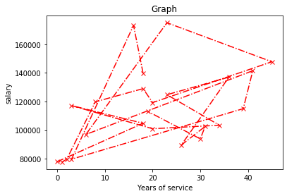

```python
plt.plot(a,b,'r',marker='x',ls='-.',lw=1.5,alpha=1)
plt.xlabel("Years of service")
plt.ylabel("salary")
plt.title("Graph")
```

This method is functional method of plotting. It Plots y versus x as lines and markers.

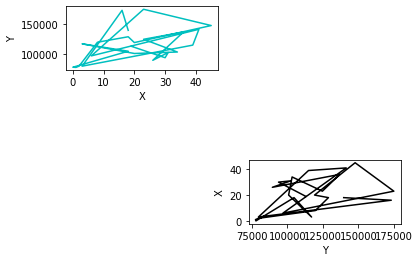

```python
plt.subplot(3,2,1)
plt.xlabel("X")
plt.ylabel("Y")
plt.plot(a,b,'c')
plt.subplot(3,2,6)
plt.plot(b,a,'k')
plt.xlabel("Y")
plt.ylabel("X")
```

It Adds a subplot to the current figure .

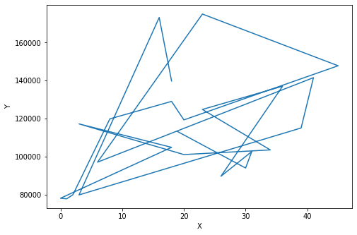

```python
fig=plt.figure()
axes=fig.add_axes([0.1,0.1,1,1])
axes.plot(a,b)
axes.set_xlabel("X")
axes.set_ylabel("Y")
```

This is Object Oriented method of ploting. It Plots y versus x as lines and/or markers.

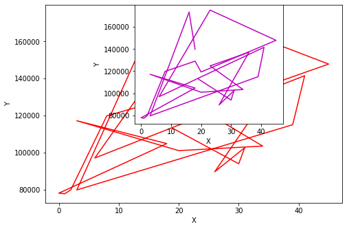

```python
fig=plt.figure()
axes=fig.add_axes([0.1,0.1,1,1])
axes2=fig.add_axes([0.4,0.5,0.5,0.6])
axes.plot(a,b,'r')
axes.set_xlabel("X")
axes.set_ylabel("Y")
axes2.plot(a,b,'m')
axes2.set_xlabel("X")
axes2.set_ylabel("Y")
```

This is also object oriented method of plotting in which a graph is drawn within a graph.

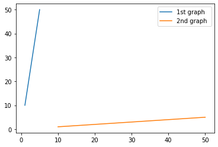

```python
e=[1,2,3,4,5]
f=[10,20,30,40,50]
plt.plot(e,f,label="1st graph ")
plt.plot(f,e,label="2nd graph ")
plt.legend(loc="best")
```

It Places a labels on the axes according to the location given . with this the matplotlib package gets over!!

# B) Seaborn:

```
Seaborn is a Python data visualization library based on matplotlib. It provides a high-level interface for drawing attractive and informative statistical graphics.
```

```python
# Distribution plot:
import seaborn as sns
%matplotlib inline
```

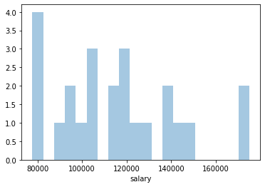

```python
sns.distplot(x["salary"],kde=False,bins=20)
```

It plots on the basis of uniform distribution. where, kde is the kernel density estimator and bins is the no of bars to be drawn. This function combines the matplotlib ``hist`` function (with automatic calculation of a good default bin size) with the seaborn :func:`kdeplot` and :func:`rugplot` functions.

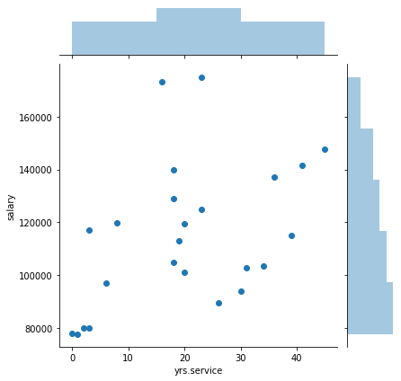

```python
sns.jointplot(x["yrs.service"],x["salary"])
```

This plot plots both the graphs on the sides if it and combines then and plots a scatterplot by default in the middle. this joins both of them and plots them.

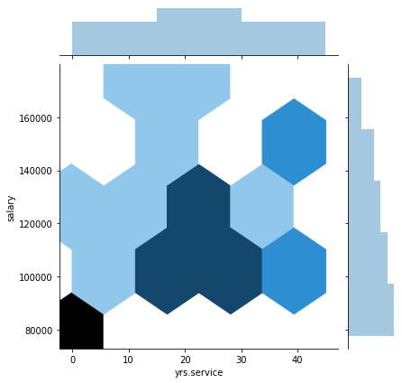

```python
sns.jointplot(x["yrs.service"],x["salary"],kind="hex")
```

This plot plots bar kind of grap on both the graphs on the sides if it, it combines then and plots a hexagonal in the middle. this joins both of them and plots them.

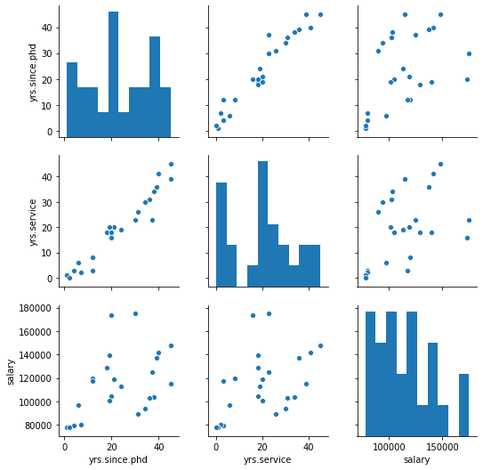

```python
sns.pairplot(x)
```

The pairplot combines all the numerical valular columns and finds the probabaility to make the no of graphs and plots them in all probablities .

```python
#categorical plot:
import seaborn as sns
%matplotlib inline
```

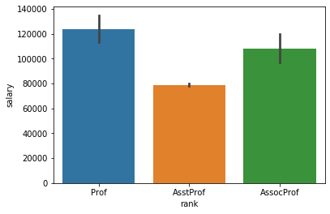

```python
sns.barplot(x="rank",y="salary",data=x)
```

A bar plot represents an estimate for a numeric variable with the height of each rectangle. Bar plots include 0 in the quantitative axis range, and they are a good choice when 0 is a meaningful value for the quantitative variable, and you want to make comparisons against it.

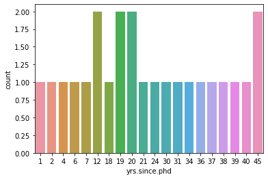

```python
sns.countplot(x="yrs.since.phd",data=x)
```

A count plot can be thought of as a histogram which is plotted on the basis of counts .

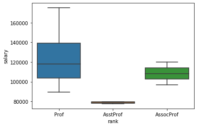

```python
sns.boxplot(x="rank",y="salary",data=x)
```

A box plot (or box-and-whisker plot) shows the distribution of quantitative data in a way that facilitates comparisons between variables or across levels of a categorical variable.

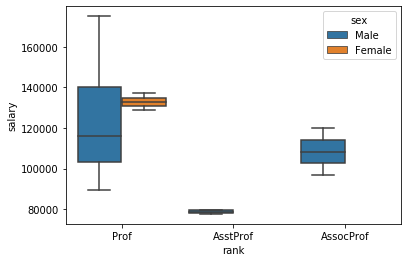

```python
sns.boxplot(x="rank",y="salary",data=x,hue='sex')
```

The box plot is further divided into two conditions such as they are male or female .

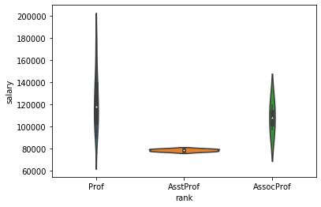

```python
sns.violinplot(x="rank",y="salary",data=x)
```

A violin plot plays a similar role as a box and whisker plot. It shows the distribution of quantitative data across several levels of one (or more) categorical variables such that those distributions can be compared.

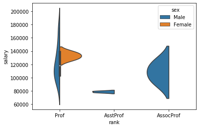

```python
sns.violinplot(x="rank",y="salary",data=x,hue='sex',split=True)
```

The violin plot is further divided into two conditions such as they are male or female .

# 15.

# Bar Graph:

```
The simplest and and most straight forward way to compare various categories is often the column-based bar graph. The graph features a series of bars of varying lengths.Bar graphs work great for visually presenting nearly any type of data, but they hold particular power in the marketing industry.
```

# # Line Graph:

Line charts, or line graphs, are powerful visual tools that illustrate trends in data over a period of time or a particular correlation. The popularity of various social-media networks over the course of a year can be visually compared with ease through the use of a line graph.

# Scatter Plots:

```
the graph consists of two axes, each representing a set of data. one axis might represent the numbers of miles driven by a vehicle, while the second axis displays the total gallons of gas used.
```

# Histogram:

```
a histogram is a special type of graph that presents numeric data and its distribution. While histograms are commonly a form of bar graph, the concept can also be applied to line graphs and other designs relying on plotting two axes.
```

# distplot:

```
When dealing with a set of data, often the first thing you’ll want to do is get a sense for how the variables are distributed. The most convenient way to take a quick look at a univariate distribution in seaborn is the distplot() function.
```

# jointplot:

```
jointplot displays a relationship between 2 variables (bivariate) as well as 1D profiles (univariate) in the margins. This plot is a convenience class that wraps JointGrid.
```

# pairplot:

```
It is used when we need to see all the combination of numerical values in a graph .
```

# Hex bin plots:

```
The bivariate analogue of a histogram is known as a “hexbin” plot, because it shows the counts of observations that fall within hexagonal bins. This plot works best with relatively large datasets.
```

# count plot:

```
A count plot can be thought of as a histogram across a categorical, instead of quantitative, variable. This function always treats one of the variables as categorical and draws data at ordinal positions (0, 1, … n) on the relevant axis, even when the data has a numeric or date type.
```

# boxplot:

```
Box and whisker plots are ideal for comparing distributions because the centre, spread and overall range are immediately apparent. A box and whisker plot is a way of summarizing a set of data measured on an interval scale. It is often used in explanatory data analysis
```

# violin plot:

```
Like box plots, violin plots are used to represent comparison of a variable distribution (or sample distribution) across different "categories" (for example, temperature distribution compared between day and night, or distribution of car prices compared across different car makers).
```

```python
# I would deal most of the datasets with bargraph because it is quite easy and understandable.
# for complex and large datasets i would prefer the usage of scatterplot as it is easy to pickup and good to see.
```